# **Problem statement**

A significant number of hotel bookings are called-off due to cancellations or no-shows. The typical reasons for cancellations include change of plans, scheduling conflicts, etc. This is often made easier by the option to do so free of charge or preferably at a low cost which is beneficial to hotel guests but it is a less desirable and possibly revenue-diminishing factor for hotels to deal with. Such losses are particularly high on last-minute cancellations.

The new technologies involving online booking channels have dramatically changed customers’ booking possibilities and behavior. This adds a further dimension to the challenge of how hotels handle cancellations, which are no longer limited to traditional booking and guest characteristics.

The cancellation of bookings impact a hotel on various fronts:

- Loss of resources (revenue) when the hotel cannot resell the room.
- Additional costs of distribution channels by increasing commissions or paying for publicity to help sell these rooms.
- Lowering prices last minute, so the hotel can resell a room, resulting in reducing the profit margin.
- Human resources to make arrangements for the guests.

# **Objective**

The increasing number of cancellations calls for a Machine Learning based solution that can help in predicting which booking is likely to be canceled. INN Hotels Group has a chain of hotels in Portugal, they are facing problems with the high number of booking cancellations and have reached out to your firm for data-driven solutions. You as a data scientist have to analyze the data provided to find which factors have a high influence on booking cancellations, build a predictive model that can predict which booking is going to be canceled in advance, and help in formulating profitable policies for cancellations and refunds.

# **Data Description**

- Booking_ID: unique identifier of each booking
- no_of_adults: Number of adults
- no_of_children: Number of Children
- no_of_weekend_nights: Number of weekend nights (Saturday or Sunday) the guest stayed or booked to stay at the hotel
- no_of_week_nights: Number of week nights (Monday to Friday) the guest stayed or booked to stay at the hotel
- type_of_meal_plan: Type of meal plan booked by the customer:
  - Not Selected – No meal plan selected
  - Meal Plan 1 – Breakfast
  - Meal Plan 2 – Half board (breakfast and one other meal)
  - Meal Plan 3 – Full board (breakfast, lunch, and dinner)
- required_car_parking_space: Does the customer require a car parking space? (0 - No, 1- Yes)
- room_type_reserved: Type of room reserved by the customer. The values are ciphered (encoded) by INN Hotels.
- lead_time: Number of days between the date of booking and the arrival date
- arrival_year: Year of arrival date
- arrival_month: Month of arrival date
- arrival_date: Date of the month
- market_segment_type: Market * segment designation.
- repeated_guest: Is the customer a repeated guest? (0 - No, 1- Yes)
- no_of_previous_cancellations: Number of previous bookings that were canceled by the customer prior to the current booking
- no_of_previous_bookings_not_canceled: Number of previous bookings not canceled by the customer prior to the current booking
- avg_price_per_room: Average price per day of the reservation; prices of the rooms are dynamic. (in euros)
- no_of_special_requests: Total number of special requests made by the customer (e.g. high floor, view from the room, etc)
- booking_status: Flag indicating if the booking was canceled or not.

```python
import pandas as pd
import numpy as np
from sklearn import metrics
import matplotlib.pyplot as plt
%matplotlib inline
import seaborn as sns
from sklearn.model_selection import train_test_split
from sklearn.tree import DecisionTreeClassifier
from sklearn import tree
pd.set_option("display.max_columns", None)
pd.set_option("display.max_rows", 200)
import warnings
warnings.filterwarnings("ignore")
from sklearn.model_selection import GridSearchCV
from sklearn.metrics import (
     f1_score,
    accuracy_score,
    recall_score,
    precision_score,
    confusion_matrix,
    roc_auc_score,
    plot_confusion_matrix,
    precision_recall_curve,
    roc_curve,
    make_scorer,
)
import statsmodels.stats.api as sms
from statsmodels.stats.outliers_influence import variance_inflation_factor
import statsmodels.api as sm
from statsmodels.tools.tools import add_constant
from sklearn.linear_model import LogisticRegression
import warnings

warnings.filterwarnings("ignore")

from statsmodels.tools.sm_exceptions import ConvergenceWarning
warnings.simplefilter("ignore", ConvergenceWarning)
```

```python
from google.colab import drive
drive.mount('/content/drive')
```

```python
df = "/content/drive/MyDrive/INNHotelsGroup.csv"
df = pd.read_csv(df)
df
```

|  | Booking_ID | no_of_adults | no_of_children | no_of_weekend_nights | no_of_week_nights | type_of_meal_plan | required_car_parking_space | room_type_reserved | lead_time | arrival_year | arrival_month | arrival_date | market_segment_type | repeated_guest | no_of_previous_cancellations | no_of_previous_bookings_not_canceled | avg_price_per_room | no_of_special_requests | booking_status |
| --- | --- | --- | --- | --- | --- | --- | --- | --- | --- | --- | --- | --- | --- | --- | --- | --- | --- | --- | --- |
| 0 | INN00001 | 2 | 0 | 1 | 2 | Meal Plan 1 | 0 | Room_Type 1 | 224 | 2017 | 10 | 2 | Offline | 0 | 0 | 0 | 65.00 | 0 | Not_Canceled |
| 1 | INN00002 | 2 | 0 | 2 | 3 | Not Selected | 0 | Room_Type 1 | 5 | 2018 | 11 | 6 | Online | 0 | 0 | 0 | 106.68 | 1 | Not_Canceled |
| 2 | INN00003 | 1 | 0 | 2 | 1 | Meal Plan 1 | 0 | Room_Type 1 | 1 | 2018 | 2 | 28 | Online | 0 | 0 | 0 | 60.00 | 0 | Canceled |
| 3 | INN00004 | 2 | 0 | 0 | 2 | Meal Plan 1 | 0 | Room_Type 1 | 211 | 2018 | 5 | 20 | Online | 0 | 0 | 0 | 100.00 | 0 | Canceled |
| 4 | INN00005 | 2 | 0 | 1 | 1 | Not Selected | 0 | Room_Type 1 | 48 | 2018 | 4 | 11 | Online | 0 | 0 | 0 | 94.50 | 0 | Canceled |
| ... | ... | ... | ... | ... | ... | ... | ... | ... | ... | ... | ... | ... | ... | ... | ... | ... | ... | ... | ... |
| 36270 | INN36271 | 3 | 0 | 2 | 6 | Meal Plan 1 | 0 | Room_Type 4 | 85 | 2018 | 8 | 3 | Online | 0 | 0 | 0 | 167.80 | 1 | Not_Canceled |
| 36271 | INN36272 | 2 | 0 | 1 | 3 | Meal Plan 1 | 0 | Room_Type 1 | 228 | 2018 | 10 | 17 | Online | 0 | 0 | 0 | 90.95 | 2 | Canceled |
| 36272 | INN36273 | 2 | 0 | 2 | 6 | Meal Plan 1 | 0 | Room_Type 1 | 148 | 2018 | 7 | 1 | Online | 0 | 0 | 0 | 98.39 | 2 | Not_Canceled |
| 36273 | INN36274 | 2 | 0 | 0 | 3 | Not Selected | 0 | Room_Type 1 | 63 | 2018 | 4 | 21 | Online | 0 | 0 | 0 | 94.50 | 0 | Canceled |
| 36274 | INN36275 | 2 | 0 | 1 | 2 | Meal Plan 1 | 0 | Room_Type 1 | 207 | 2018 | 12 | 30 | Offline | 0 | 0 | 0 | 161.67 | 0 | Not_Canceled |

36275 rows × 19 columns

```python
inn = df.copy()
```

```python
inn.head()
```

|  | Booking_ID | no_of_adults | no_of_children | no_of_weekend_nights | no_of_week_nights | type_of_meal_plan | required_car_parking_space | room_type_reserved | lead_time | arrival_year | arrival_month | arrival_date | market_segment_type | repeated_guest | no_of_previous_cancellations | no_of_previous_bookings_not_canceled | avg_price_per_room | no_of_special_requests | booking_status |
| --- | --- | --- | --- | --- | --- | --- | --- | --- | --- | --- | --- | --- | --- | --- | --- | --- | --- | --- | --- |
| 0 | INN00001 | 2 | 0 | 1 | 2 | Meal Plan 1 | 0 | Room_Type 1 | 224 | 2017 | 10 | 2 | Offline | 0 | 0 | 0 | 65.00 | 0 | Not_Canceled |
| 1 | INN00002 | 2 | 0 | 2 | 3 | Not Selected | 0 | Room_Type 1 | 5 | 2018 | 11 | 6 | Online | 0 | 0 | 0 | 106.68 | 1 | Not_Canceled |
| 2 | INN00003 | 1 | 0 | 2 | 1 | Meal Plan 1 | 0 | Room_Type 1 | 1 | 2018 | 2 | 28 | Online | 0 | 0 | 0 | 60.00 | 0 | Canceled |
| 3 | INN00004 | 2 | 0 | 0 | 2 | Meal Plan 1 | 0 | Room_Type 1 | 211 | 2018 | 5 | 20 | Online | 0 | 0 | 0 | 100.00 | 0 | Canceled |
| 4 | INN00005 | 2 | 0 | 1 | 1 | Not Selected | 0 | Room_Type 1 | 48 | 2018 | 4 | 11 | Online | 0 | 0 | 0 | 94.50 | 0 | Canceled |

```python
inn.tail()
```

|  | Booking_ID | no_of_adults | no_of_children | no_of_weekend_nights | no_of_week_nights | type_of_meal_plan | required_car_parking_space | room_type_reserved | lead_time | arrival_year | arrival_month | arrival_date | market_segment_type | repeated_guest | no_of_previous_cancellations | no_of_previous_bookings_not_canceled | avg_price_per_room | no_of_special_requests | booking_status |
| --- | --- | --- | --- | --- | --- | --- | --- | --- | --- | --- | --- | --- | --- | --- | --- | --- | --- | --- | --- |
| 36270 | INN36271 | 3 | 0 | 2 | 6 | Meal Plan 1 | 0 | Room_Type 4 | 85 | 2018 | 8 | 3 | Online | 0 | 0 | 0 | 167.80 | 1 | Not_Canceled |
| 36271 | INN36272 | 2 | 0 | 1 | 3 | Meal Plan 1 | 0 | Room_Type 1 | 228 | 2018 | 10 | 17 | Online | 0 | 0 | 0 | 90.95 | 2 | Canceled |
| 36272 | INN36273 | 2 | 0 | 2 | 6 | Meal Plan 1 | 0 | Room_Type 1 | 148 | 2018 | 7 | 1 | Online | 0 | 0 | 0 | 98.39 | 2 | Not_Canceled |
| 36273 | INN36274 | 2 | 0 | 0 | 3 | Not Selected | 0 | Room_Type 1 | 63 | 2018 | 4 | 21 | Online | 0 | 0 | 0 | 94.50 | 0 | Canceled |
| 36274 | INN36275 | 2 | 0 | 1 | 2 | Meal Plan 1 | 0 | Room_Type 1 | 207 | 2018 | 12 | 30 | Offline | 0 | 0 | 0 | 161.67 | 0 | Not_Canceled |

```python
inn.shape
```

```
(36275, 19)
```

- The dataset has 36275 rows and 19 columns of data.

```python
inn.info()
```

```
<class 'pandas.core.frame.DataFrame'>
RangeIndex: 36275 entries, 0 to 36274
Data columns (total 19 columns):
 #   Column                                Non-Null Count  Dtype
---  ------                                --------------  -----
 0   Booking_ID                            36275 non-null  object
 1   no_of_adults                          36275 non-null  int64
 2   no_of_children                        36275 non-null  int64
 3   no_of_weekend_nights                  36275 non-null  int64
 4   no_of_week_nights                     36275 non-null  int64
 5   type_of_meal_plan                     36275 non-null  object
 6   required_car_parking_space            36275 non-null  int64
 7   room_type_reserved                    36275 non-null  object
 8   lead_time                             36275 non-null  int64
 9   arrival_year                          36275 non-null  int64
 10  arrival_month                         36275 non-null  int64
 11  arrival_date                          36275 non-null  int64
 12  market_segment_type                   36275 non-null  object
 13  repeated_guest                        36275 non-null  int64
 14  no_of_previous_cancellations          36275 non-null  int64
 15  no_of_previous_bookings_not_canceled  36275 non-null  int64
 16  avg_price_per_room                    36275 non-null  float64
 17  no_of_special_requests                36275 non-null  int64
 18  booking_status                        36275 non-null  object
dtypes: float64(1), int64(13), object(5)
memory usage: 5.3+ MB
```

```python
inn[inn.duplicated()].count()
```

```
Booking_ID                              0
no_of_adults                            0
no_of_children                          0
no_of_weekend_nights                    0
no_of_week_nights                       0
type_of_meal_plan                       0
required_car_parking_space              0
room_type_reserved                      0
lead_time                               0
arrival_year                            0
arrival_month                           0
arrival_date                            0
market_segment_type                     0
repeated_guest                          0
no_of_previous_cancellations            0
no_of_previous_bookings_not_canceled    0
avg_price_per_room                      0
no_of_special_requests                  0
booking_status                          0
dtype: int64
```

```python
inn.describe(include="all")
```

|  | Booking_ID | no_of_adults | no_of_children | no_of_weekend_nights | no_of_week_nights | type_of_meal_plan | required_car_parking_space | room_type_reserved | lead_time | arrival_year | arrival_month | arrival_date | market_segment_type | repeated_guest | no_of_previous_cancellations | no_of_previous_bookings_not_canceled | avg_price_per_room | no_of_special_requests | booking_status |
| --- | --- | --- | --- | --- | --- | --- | --- | --- | --- | --- | --- | --- | --- | --- | --- | --- | --- | --- | --- |
| count | 36275 | 36275.000000 | 36275.000000 | 36275.000000 | 36275.000000 | 36275 | 36275.000000 | 36275 | 36275.000000 | 36275.000000 | 36275.000000 | 36275.000000 | 36275 | 36275.000000 | 36275.000000 | 36275.000000 | 36275.000000 | 36275.000000 | 36275 |
| unique | 36275 | NaN | NaN | NaN | NaN | 4 | NaN | 7 | NaN | NaN | NaN | NaN | 5 | NaN | NaN | NaN | NaN | NaN | 2 |
| top | INN00001 | NaN | NaN | NaN | NaN | Meal Plan 1 | NaN | Room_Type 1 | NaN | NaN | NaN | NaN | Online | NaN | NaN | NaN | NaN | NaN | Not_Canceled |
| freq | 1 | NaN | NaN | NaN | NaN | 27835 | NaN | 28130 | NaN | NaN | NaN | NaN | 23214 | NaN | NaN | NaN | NaN | NaN | 24390 |
| mean | NaN | 1.844962 | 0.105279 | 0.810724 | 2.204300 | NaN | 0.030986 | NaN | 85.232557 | 2017.820427 | 7.423653 | 15.596995 | NaN | 0.025637 | 0.023349 | 0.153411 | 103.423539 | 0.619655 | NaN |
| std | NaN | 0.518715 | 0.402648 | 0.870644 | 1.410905 | NaN | 0.173281 | NaN | 85.930817 | 0.383836 | 3.069894 | 8.740447 | NaN | 0.158053 | 0.368331 | 1.754171 | 35.089424 | 0.786236 | NaN |
| min | NaN | 0.000000 | 0.000000 | 0.000000 | 0.000000 | NaN | 0.000000 | NaN | 0.000000 | 2017.000000 | 1.000000 | 1.000000 | NaN | 0.000000 | 0.000000 | 0.000000 | 0.000000 | 0.000000 | NaN |
| 25% | NaN | 2.000000 | 0.000000 | 0.000000 | 1.000000 | NaN | 0.000000 | NaN | 17.000000 | 2018.000000 | 5.000000 | 8.000000 | NaN | 0.000000 | 0.000000 | 0.000000 | 80.300000 | 0.000000 | NaN |
| 50% | NaN | 2.000000 | 0.000000 | 1.000000 | 2.000000 | NaN | 0.000000 | NaN | 57.000000 | 2018.000000 | 8.000000 | 16.000000 | NaN | 0.000000 | 0.000000 | 0.000000 | 99.450000 | 0.000000 | NaN |
| 75% | NaN | 2.000000 | 0.000000 | 2.000000 | 3.000000 | NaN | 0.000000 | NaN | 126.000000 | 2018.000000 | 10.000000 | 23.000000 | NaN | 0.000000 | 0.000000 | 0.000000 | 120.000000 | 1.000000 | NaN |
| max | NaN | 4.000000 | 10.000000 | 7.000000 | 17.000000 | NaN | 1.000000 | NaN | 443.000000 | 2018.000000 | 12.000000 | 31.000000 | NaN | 1.000000 | 13.000000 | 58.000000 | 540.000000 | 5.000000 | NaN |

```python
inn.isnull().sum()
```

[output not shown]

- There are no missing values.

#### Grouping and dropping for EDA

```python
inn.drop(["Booking_ID"], axis=1, inplace=True)
```

```python
inn[["required_car_parking_space", "arrival_year", "arrival_month", "arrival_date", "repeated_guest"]] = \
inn[["required_car_parking_space", "arrival_year", "arrival_month", "arrival_date", "repeated_guest"]]\
.astype("category")
```

```python
inn[["type_of_meal_plan", "room_type_reserved", "market_segment_type", "booking_status"]] = \
inn[["type_of_meal_plan", "room_type_reserved", "market_segment_type", "booking_status"]].astype("category")
```

```python
cat_columns = inn.describe(include="category").columns
cat_columns
```

```
Index(['type_of_meal_plan', 'required_car_parking_space', 'room_type_reserved',
       'arrival_year', 'arrival_month', 'arrival_date', 'market_segment_type',
       'repeated_guest', 'booking_status'],
      dtype='object')
```

# **Exploratory Data Analysis (EDA)**

```python
def labeled_barplot(data, feature, perc=False, n=None):
    """
    Barplot with percentage at the top

    data: dataframe
    feature: dataframe column
    perc: whether to display percentages instead of count (default is False)
    n: displays the top n category levels (default is None, i.e., display all levels)
    """

    total = len(data[feature])
    count = data[feature].nunique()
    if n is None:
        plt.figure(figsize=(count + 2, 6))
    else:
        plt.figure(figsize=(n + 2, 6))

    plt.xticks(rotation=90, fontsize=15)
    ax = sns.countplot(
        data=data,
        x=feature,
        palette="Paired",
        order=data[feature].value_counts().index[:n],
    )

    for p in ax.patches:
        if perc == True:
            label = "{:.1f}%".format(
                100 * p.get_height() / total
            )
        else:
            label = p.get_height()

        x = p.get_x() + p.get_width() / 2
        y = p.get_height()

        ax.annotate(
            label,
            (x, y),
            ha="center",
            va="center",
            size=12,
            xytext=(0, 5),
            textcoords="offset points",
        )

    plt.show()
```

```python
def stacked_barplot(data, predictor, target):
    """
    Print the category counts and plot a stacked bar chart

    data: dataframe
    predictor: independent variable
    target: target variable
    """
    count = data[predictor].nunique()
    sorter = data[target].value_counts().index[-1]
    tab1 = pd.crosstab(data[predictor], data[target], margins=True).sort_values(
        by=sorter, ascending=False
    )
    print(tab1)
    print("-" * 120)
    tab = pd.crosstab(data[predictor], data[target], normalize="index").sort_values(
        by=sorter, ascending=False
    )
    tab.plot(kind="bar", stacked=True, figsize=(count + 5, 6))
    plt.legend(
        loc="lower left", frameon=False,
    )
    plt.legend(loc="upper left", bbox_to_anchor=(1, 1))
    plt.show()
```

```python
def histogram_boxplot(data, feature, figsize=(12, 7), kde=False, bins=None):
    """
    Boxplot and histogram combined

    data: dataframe
    feature: dataframe column
    figsize: size of figure (default (12,7))
    kde: whether to the show density curve (default False)
    bins: number of bins for histogram (default None)
    """
    f2, (ax_box2, ax_hist2) = plt.subplots(
        nrows=2,
        sharex=True,
        gridspec_kw={"height_ratios": (0.25, 0.75)},
        figsize=figsize,
    )
    sns.boxplot(
        data=data, x=feature, ax=ax_box2, showmeans=True, color="violet"
    )
    sns.histplot(
        data=data, x=feature, kde=kde, ax=ax_hist2, bins=bins, palette="winter"
    ) if bins else sns.histplot(
        data=data, x=feature, kde=kde, ax=ax_hist2
    )
    ax_hist2.axvline(
        data[feature].mean(), color="green", linestyle="--"
    )
    ax_hist2.axvline(
        data[feature].median(), color="black", linestyle="-"
    )
```

## **Univariate analysis**

### Number of Adults

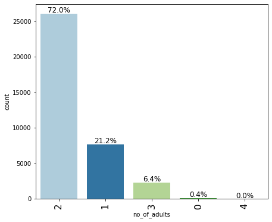

```python
labeled_barplot(inn,"no_of_adults", perc=True)
```

- The large group of booking are for two adults which is likely for couples.

### Number of Children

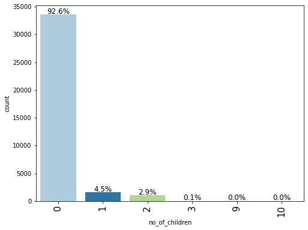

```python
labeled_barplot(inn,"no_of_children", perc=True)
```

- Most bookings do not include children. This variable does mot impact booking retention

### Number of weekend nights

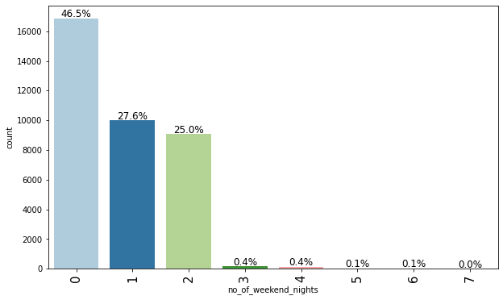

```python
labeled_barplot(inn,"no_of_weekend_nights", perc=True)
```

- Approximatly half of the booking does not include weekend night. Some reservations include 1 or 2 weekend days.

### Number of weeknights

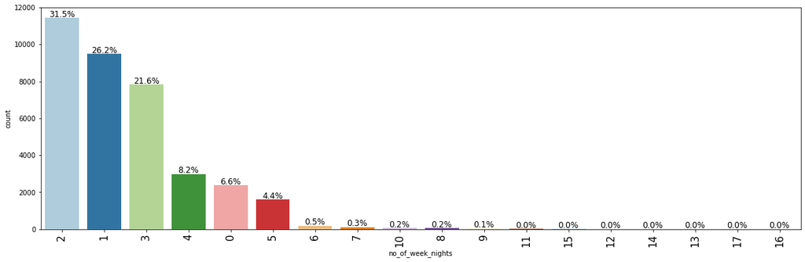

```python
labeled_barplot(inn,"no_of_week_nights", perc=True)
```

- Most weeknight booking were made for 2 nights. while 1 and 3 weeknight booking were made about 50% of the time.

### Type of meal plan

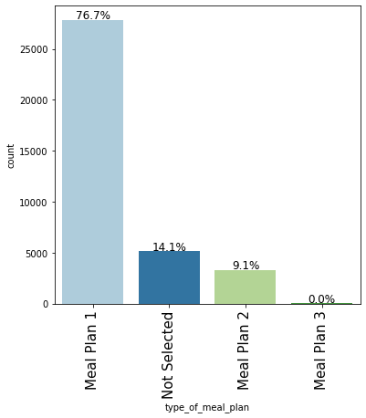

```python
labeled_barplot(inn,"type_of_meal_plan", perc=True)
```

- Meal plan 1 or breakfast has the most booking while meal plan 2 (half board) were selected by 9.1% of customers.
- Meal plan 3(full board) were not selected by customers and 14.1% of customers did not select a meal plan. This can be due to price.

### Required car Parking space

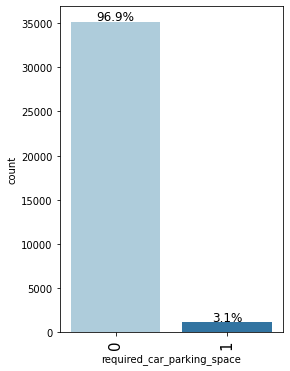

```python
labeled_barplot(inn,"required_car_parking_space", perc=True)
```

- Most booking have not requested a parking space.

### Room type reserved

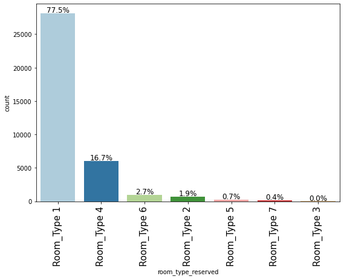

```python
labeled_barplot(inn,"room_type_reserved", perc=True)
```

- Most booking are for room type 1 followed by room type 4 and type 6.

### Number of special requests

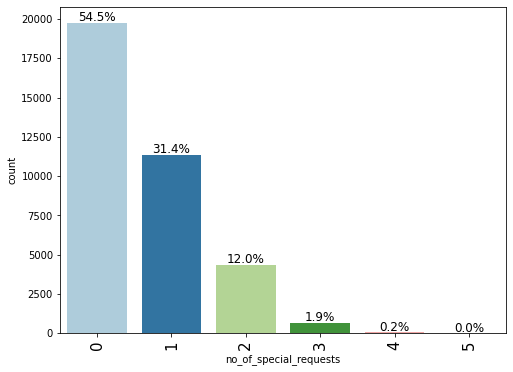

```python
labeled_barplot(inn,"no_of_special_requests", perc=True)
```

- Most booking have no special request. 31.4% have one, 12% have 2 and 1.9% have 3 special requests.

### Arrival year

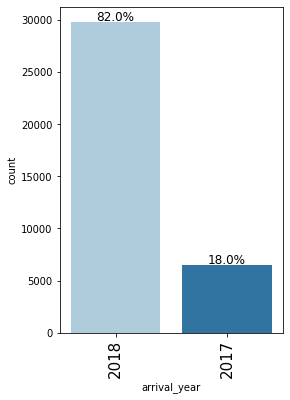

```python
labeled_barplot(inn,"arrival_year", perc=True)
```

- Most booking were made in 2018 compared to 2017

### Arrival month

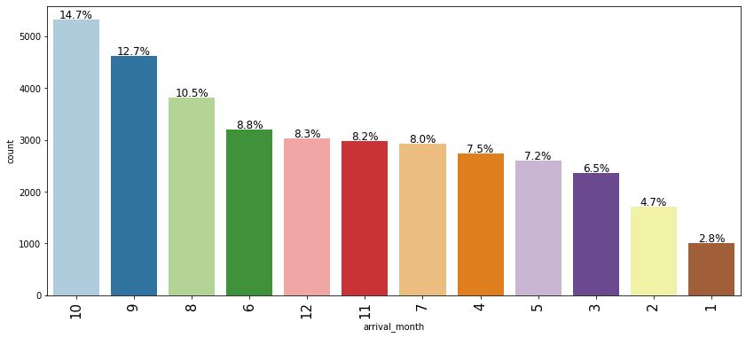

```python
labeled_barplot(inn,"arrival_month", perc=True)
```

### Arrival date

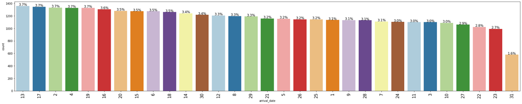

```python
labeled_barplot(inn,"arrival_date", perc=True)
```

- It seems like arrival data has no impact on booking retention.

### Market segment type

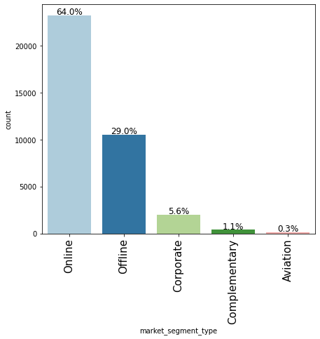

```python
labeled_barplot(inn,"market_segment_type", perc=True)
```

- Most booking were made online followed by offline and corporate.
- Since booking online is popular, cancelling online is also convient. Focusing on online booking can help us improve booking retention.

### Booking status

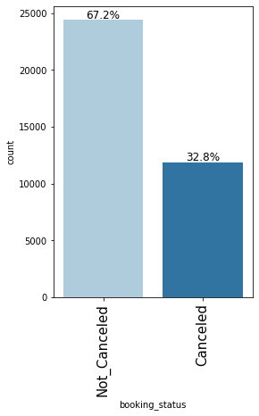

```python
labeled_barplot(inn,"booking_status", perc=True)
```

- 32.8% of booking are cancelled and the majority, which is 67.2% are retained.

### Lead Time

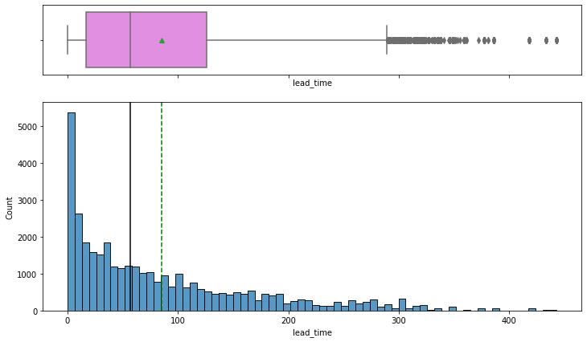

```python
histogram_boxplot(inn, 'lead_time')
```

### Average Price per room

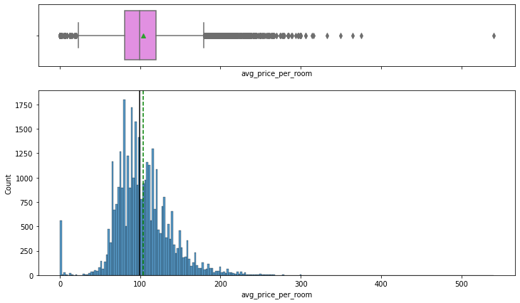

```python
histogram_boxplot(inn, 'avg_price_per_room')
```

### Number of previous booking cancellations

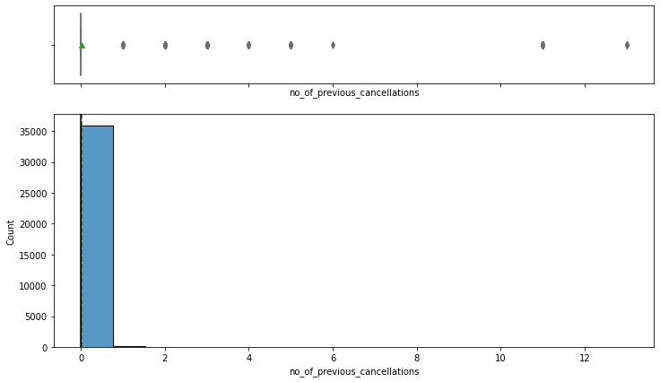

```python
histogram_boxplot(inn, 'no_of_previous_cancellations')
```

```python
inn['no_of_previous_cancellations'].describe()
```

```
count    36275.000000
mean         0.023349
std          0.368331
min          0.000000
25%          0.000000
50%          0.000000
75%          0.000000
max         13.000000
Name: no_of_previous_cancellations, dtype: float64
```

- The mean and the median is zero.
- Outliers are present on the the plot as the max valus is 13.

### Number of previous booking not cancelled

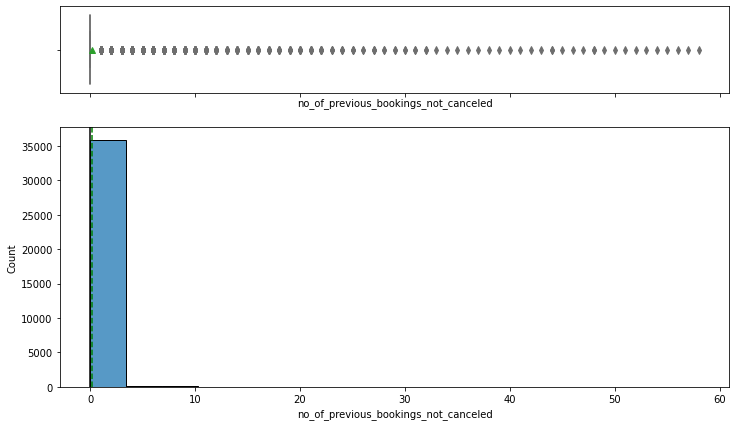

```python
histogram_boxplot(inn, 'no_of_previous_bookings_not_canceled')
```

```python
inn['no_of_previous_bookings_not_canceled'].describe()
```

```
count    36275.000000
mean         0.153411
std          1.754171
min          0.000000
25%          0.000000
50%          0.000000
75%          0.000000
max         58.000000
Name: no_of_previous_bookings_not_canceled, dtype: float64
```

# Bivariate Analysis

### Market segment type and average price per room

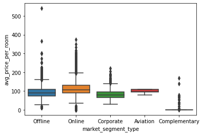

```python
sns.boxplot(data=inn, y='avg_price_per_room' , x='market_segment_type')
```

- Online booking brings in the highest average price per room.

### Market segment type and booking status

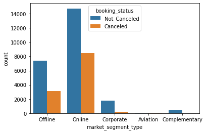

```python
sns.countplot(data=df, x='market_segment_type',hue='booking_status')
```

- Online booking has the highest amount of canceled and not canceled values.
- Complementary room booking has no cancellation as it is free of charge.

### Number of special request and average price per room

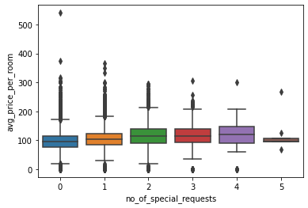

```python
sns.boxplot(data=inn, y='avg_price_per_room' , x='no_of_special_requests')
```

- As the number of special request increase, the average price per room increases.

### Number of special request and booking status

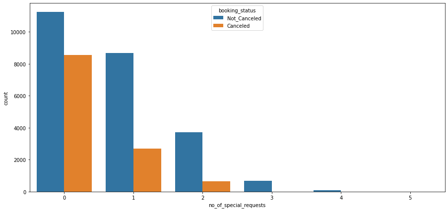

```python
plt.figure(figsize=(15, 7))
sns.countplot(data=df, x='no_of_special_requests',hue='booking_status')
```

- The more a customer makes special request the least probability the for cancellation.

### Average price per room and booking status

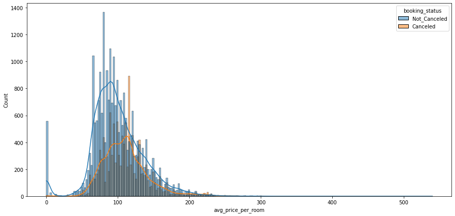

```python
plt.figure(figsize=(15,7))
sns.histplot(data=inn,x='avg_price_per_room', hue='booking_status',kde=True)
plt.show()
```

- The more a room cost the higher customers cancel their booking.

### Lead time and booking status

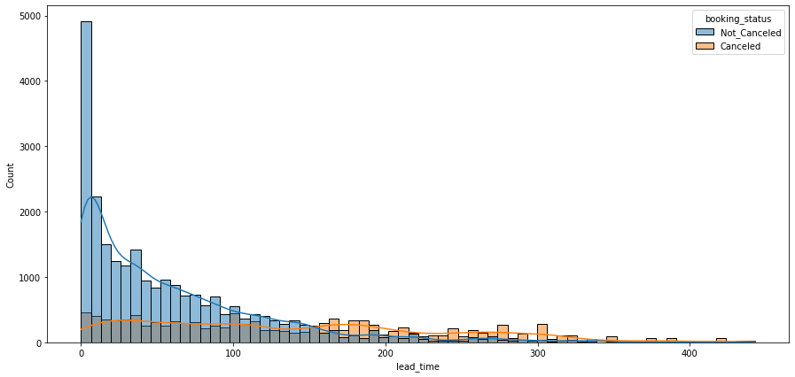

```python
plt.figure(figsize=(15, 7))
sns.histplot(data=inn,x='lead_time', hue='booking_status',kde=True)
plt.show()
```

- Lead time and booking status has a relationship that can impact booking retention.
- Customers with shorter lead time tend not to cancel their booking while customers with longer lead time tend to have a higher chance of cancelling.

### Repeated guest and booking status

```
booking_status  Canceled  Not_Canceled    All
repeated_guest
All                11885         24390  36275
0                  11869         23476  35345
1                     16           914    930
------------------------------------------------------------------------------------------------------------------------
```

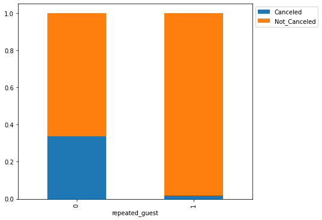

```python
stacked_barplot(inn,'repeated_guest','booking_status')
```

- Repeated guest tend to cancel their bookings less often.

### Number of week nights and booking status.

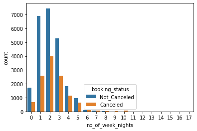

```python
sns.countplot(data=inn, x='no_of_week_nights',hue='booking_status')
```

- Most of the rooms that were booked for week nights were not cnaceled. But the number of week nights increase, the more customers tend to cancel their booking.

### Number of weekend nights and booking status

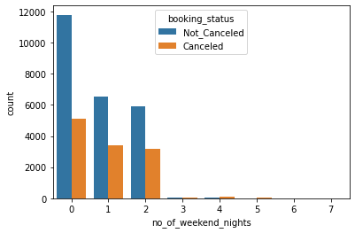

```python
sns.countplot(data=inn, x='no_of_weekend_nights',hue='booking_status')
```

- Simlar to week nights, weekend nights booking tend to get cancelled as the number of booked nights increase.

### Arrival month and Average price per room.

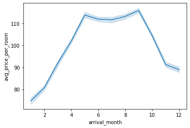

```python
sns.lineplot(data = inn,x='arrival_month',y= 'avg_price_per_room')
```

### Correlation

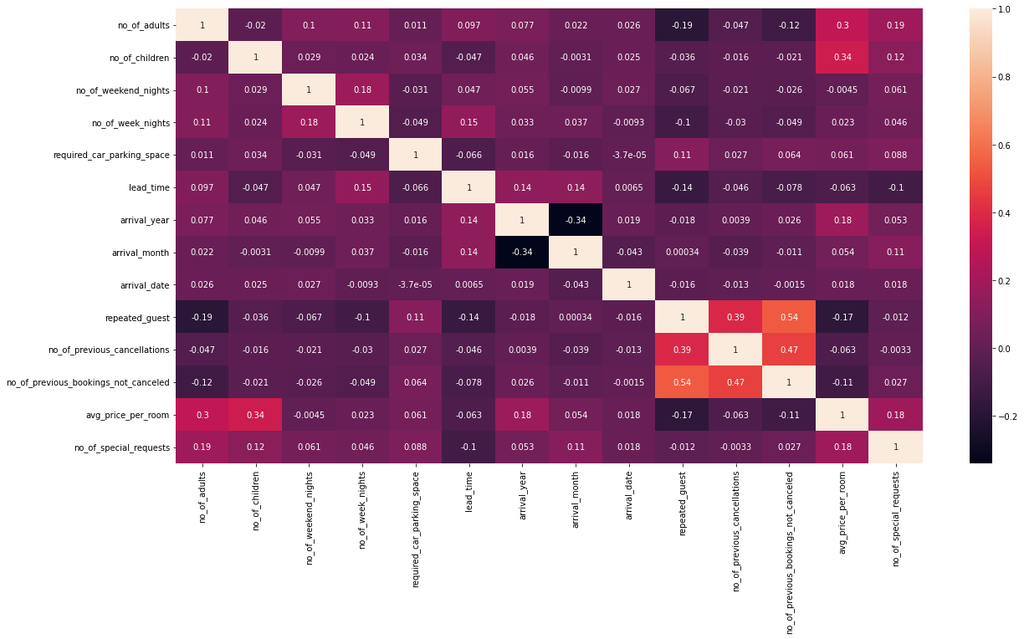

```python
plt.figure(figsize=(20,10))
sns.heatmap(
inn.corr(), annot=True)
```

- The highest correlation is between the number of previous booking and reapted guest.
- Strong relationship observed between previous bookings not canceled & repeated guest.

### **Leading Questions:**

- What are the busiest months in the hotel?
  - **October with 14.7% of the total booking for the year.**
- Which market segment do most of the guests come from?
  - **Online with 64% of the bookings**
- Hotel rates are dynamic and change according to demand and customer demographics. What are the differences in room prices in different market segments?
  - **Online booking generate the highest money. Aviation, offline, and corporate are cheaper.Complimentary are free.**
- What percentage of bookings are canceled?
  - 32.8%
- Repeating guests are the guests who stay in the hotel often and are important to brand equity. What percentage of repeating guests cancel?
  - **only 16 out of 930 repeating guest cancelled which is 1.72%**
- Many guests have special requirements when booking a hotel room. Do these requirements affect booking cancellation?
  - **Guest with no sepcial request tend to cancel their booking. But as the guest make more request, they tend not to cancel their booking.**

# **Data Preprocessing**

- Since there are no missing values we will do outlier detection.

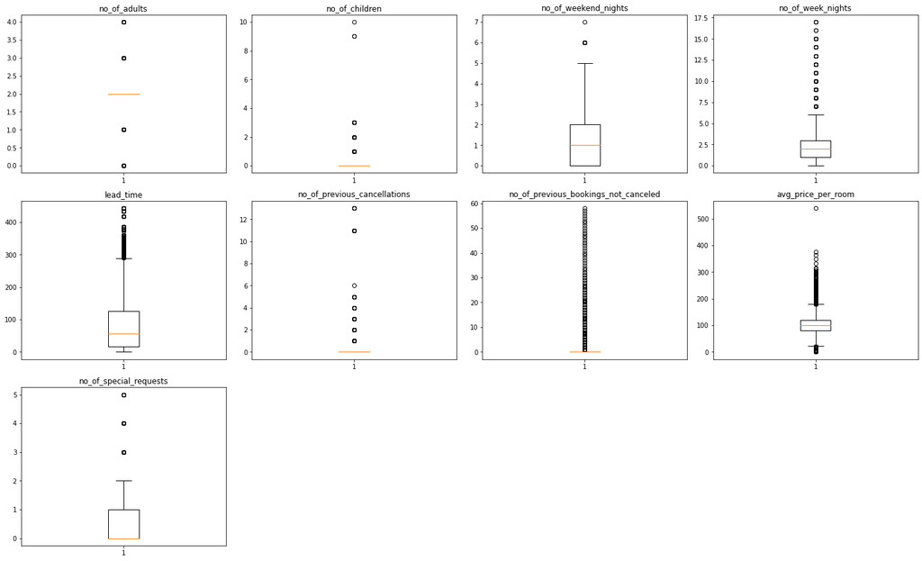

```python
plt.figure(figsize=(20, 20))
numeric_columns = inn.select_dtypes(include=np.number).columns.tolist()
for i, variable in enumerate(numeric_columns):
    plt.subplot(5, 4, i + 1)
    plt.boxplot(inn[variable], whis=1.5)
    plt.tight_layout()
    plt.title(variable)
plt.show()
```

- Number of Week nights, Lead Time,number of previous cancellation, number of previous booking not cancelled and average price per room have the most outliers.
- Some of these outliers for necessary for analysis so i will only be treating no_of_weekend_nights, no_of_week_nights.

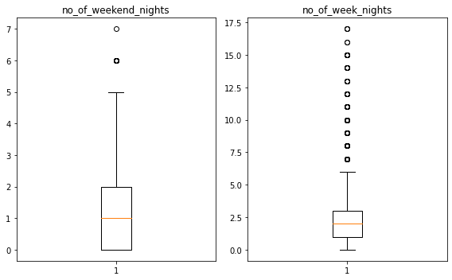

```python
week_col = ["no_of_weekend_nights", "no_of_week_nights"]
plt.figure(figsize=(8, 5))

for i, variable in enumerate(week_col):
    plt.subplot(1, 2, i + 1)
    plt.boxplot(inn[variable], whis=1.5)
    plt.tight_layout()
    plt.title(variable)

plt.show()
```

```python
def treat_outliers(df, col):
    """
    Treats outliers in a variable

    df: dataframe
    col: dataframe column
    """
    Q1 = df[col].quantile(0.25)
    Q3 = df[col].quantile(0.75)
    IQR = Q3 - Q1
    Lower_Whisker = Q1 - 1.5 * IQR
    Upper_Whisker = Q3 + 1.5 * IQR


    df[col] = np.clip(df[col], Lower_Whisker, Upper_Whisker)

    return df


def treat_outliers_all(df, col_list):
    """
    Treat outliers in a list of variables

    df: dataframe
    col_list: list of dataframe columns
    """
    for c in col_list:
        df = treat_outliers(df, c)

    return df

data = treat_outliers_all(inn, week_col)
```

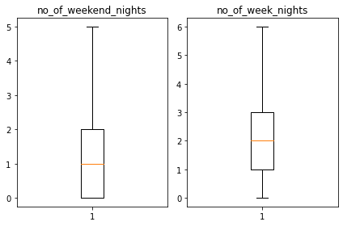

```python
for i, variable in enumerate(week_col):
    plt.subplot(1, 2, i + 1)
    plt.boxplot(data[variable], whis=1.5)
    plt.tight_layout()
    plt.title(variable)

plt.show()
```

EDA numerical variables

[figure not shown]

```python
inn_numcols = [
    item for item in inn.select_dtypes(include=np.number).columns
]

plt.figure(figsize=(15, 45))

for i in range(len(inn_numcols)):
    plt.subplot(12, 3, i + 1)
    plt.hist(inn[inn_numcols[i]], bins=50)
    plt.tight_layout()
    plt.title(inn_numcols[i], fontsize=15)

plt.show()
```

```python
inn["booking_status"] = inn["booking_status"].apply(lambda x: 0 if x == "Canceled" else 1)
```

```python
inn2= inn.copy()
```

### Creating new columns with actual values and data types

- Grouping the months in terms of season for simplification.

```python
inn2["arrival_month"] = inn2["arrival_month"].astype("object")

inn2.loc[inn2.arrival_month==1, "arrival_month"] = "Winter"
inn2.loc[inn2.arrival_month==2, "arrival_month"] = "Winter"
inn2.loc[inn2.arrival_month==3, "arrival_month"] = "Spring"
inn2.loc[inn2.arrival_month==4, "arrival_month"] = "Spring"
inn2.loc[inn2.arrival_month==5, "arrival_month"] = "Spring"
inn2.loc[inn2.arrival_month==6, "arrival_month"] = "Summer"
inn2.loc[inn2.arrival_month==7, "arrival_month"] = "Summer"
inn2.loc[inn2.arrival_month==8, "arrival_month"] = "Summer"
inn2.loc[inn2.arrival_month==9, "arrival_month"] = "Fall"
inn2.loc[inn2.arrival_month==10, "arrival_month"] = "Fall"
inn2.loc[inn2.arrival_month==11, "arrival_month"] = "Fall"
inn2.loc[inn2.arrival_month==12, "arrival_month"] = "Winter"

inn2["arrival_month"] = inn2["arrival_month"].astype("category")
```

- Dropping the arrival date and year to minimize the number columns

```python
inn2 = inn2.drop(["arrival_year", "arrival_date"],axis=1)
```

Drooping the orignal lead time and calculating the cube root this array

```python
inn2["cbrt_lead_time"] = np.cbrt(inn2["lead_time"])
inn2.drop("lead_time", axis=1, inplace=True)
```

Binning & converting to categorical column.

```python
inn2["no_of_previous_cancellations_binned"] = pd.cut( inn2["no_of_previous_cancellations"], \
                                              [-np.inf, 0, 1, np.inf], \
                                              labels = ["0_canceled_prior_bookings", \
                                                        "1_canceled_prior_bookings", \
                                                        ">1_canceled_prior_bookings"])

inn2["no_of_previous_bookings_not_canceled_binned"] = pd.cut( inn2["no_of_previous_bookings_not_canceled"],\
                                                      [-np.inf, 0, 35, np.inf], \
                                                      labels = ["0_uncanceled_prior_bookings", \
                                                                "<35_uncanceled_prior_bookings",
                                                                ">35_uncanceled_prior_bookings"])
```

```python
inn2["no_of_previous_cancellations_binned"] = inn2["no_of_previous_cancellations_binned"].astype("category")
inn2["no_of_previous_bookings_not_canceled_binned"] = inn2["no_of_previous_bookings_not_canceled_binned"].\
                                                      astype("category")

inn2.drop("no_of_previous_cancellations", axis=1, inplace=True)
inn2.drop("no_of_previous_bookings_not_canceled", axis=1, inplace=True)
```

```python
inn2.drop("no_of_previous_bookings_not_canceled_binned", axis=1, inplace=True)
```

### Encode categorical features.

```python
X = inn2.drop(["booking_status"], axis=1)
y = inn2["booking_status"]
print(X.head())
print(y.head())
```

```
   no_of_adults  no_of_children  no_of_weekend_nights  no_of_week_nights  \
0             2               0                   1.0                2.0
1             2               0                   2.0                3.0
2             1               0                   2.0                1.0
3             2               0                   0.0                2.0
4             2               0                   1.0                1.0

  type_of_meal_plan required_car_parking_space room_type_reserved  \
0       Meal Plan 1                          0        Room_Type 1
1      Not Selected                          0        Room_Type 1
2       Meal Plan 1                          0        Room_Type 1
3       Meal Plan 1                          0        Room_Type 1
4      Not Selected                          0        Room_Type 1

  arrival_month market_segment_type repeated_guest  avg_price_per_room  \
```

[output cut: 19 more lines]

```python
X = pd.get_dummies(X, drop_first=True)
```

```python
X.info()
```

```
<class 'pandas.core.frame.DataFrame'>
RangeIndex: 36275 entries, 0 to 36274
Data columns (total 27 columns):
 #   Column                                                          Non-Null Count  Dtype
---  ------                                                          --------------  -----
 0   no_of_adults                                                    36275 non-null  int64
 1   no_of_children                                                  36275 non-null  int64
 2   no_of_weekend_nights                                            36275 non-null  float64
 3   no_of_week_nights                                               36275 non-null  float64
 4   avg_price_per_room                                              36275 non-null  float64
 5   no_of_special_requests                                          36275 non-null  int64
 6   cbrt_lead_time                                                  36275 non-null  float64
 7   type_of_meal_plan_Meal Plan 2                                   36275 non-null  uint8
 8   type_of_meal_plan_Meal Plan 3                                   36275 non-null  uint8
 9   type_of_meal_plan_Not Selected                                  36275 non-null  uint8
```

[output cut: 19 more lines]

```python
X_train, X_test, y_train, y_test = train_test_split(X, y, test_size=0.3, random_state=1)
```

Splitting the data in 70:30 ratio for train to test data

```python
print("Number of rows in train data =", X_train.shape[0])
print("Number of rows in test data =", X_test.shape[0])
```

```
Number of rows in train data = 25392
Number of rows in test data = 10883
```

```python
print("Percentage of classes in training set:")
print(y_train.value_counts(normalize=True))
print("Percentage of classes in test set:")
print(y_test.value_counts(normalize=True))
```

```
Percentage of classes in training set:
1    0.670644
0    0.329356
Name: booking_status, dtype: float64
Percentage of classes in test set:
1    0.676376
0    0.323624
Name: booking_status, dtype: float64
```

# Checking Multicollinearity

```python
vif_series = pd.Series(
    [variance_inflation_factor(X.values, i) for i in range(X.shape[1])],
    index=X.columns,
    dtype=float,
)
print("Series before feature selection: \n\n{}\n".format(vif_series))
```

```
Series before feature selection:

no_of_adults                                                      18.569232
no_of_children                                                     2.150553
no_of_weekend_nights                                               1.963090
no_of_week_nights                                                  4.239384
avg_price_per_room                                                19.448447
no_of_special_requests                                             2.016109
cbrt_lead_time                                                     8.127419
type_of_meal_plan_Meal Plan 2                                      1.306867
type_of_meal_plan_Meal Plan 3                                      1.018181
type_of_meal_plan_Not Selected                                     1.443156
required_car_parking_space_1                                       1.073064
room_type_reserved_Room_Type 2                                     1.114484
room_type_reserved_Room_Type 3                                     1.002202
room_type_reserved_Room_Type 4                                     1.630195
room_type_reserved_Room_Type 5                                     1.037076
room_type_reserved_Room_Type 6                                     2.042082
room_type_reserved_Room_Type 7                                     1.113283
arrival_month_Spring                                               1.652380
arrival_month_Summer                                               1.834798
arrival_month_Winter                                               1.624938
market_segment_type_Complementary                                  1.245273
market_segment_type_Corporate                                      2.524614
market_segment_type_Offline                                       10.871349
market_segment_type_Online                                        27.015673
repeated_guest_1                                                   2.002465
no_of_previous_cancellations_binned_1_canceled_prior_bookings      1.356752
no_of_previous_cancellations_binned_>1_canceled_prior_bookings     1.242998
dtype: float64
```

- Columns with very high VIF values indicate presence of strong multicollinearity.
- We will drop these columns with VIF > 5.
- no_of_adults, avg_price_per_room, cbrt_lead_time, market_segment_type_Online, market_segment_type_offline have high VIF

Dropping market_segment_type_Online

```python
X.drop("market_segment_type_Online", axis=1, inplace=True)

vif_series = pd.Series(
    [variance_inflation_factor(X.values, i) for i in range(X.shape[1])],
    index=X.columns,
    dtype=float,
)
print("Series before feature selection: \n\n{}\n".format(vif_series))
```

```
Series before feature selection:

no_of_adults                                                      15.713006
no_of_children                                                     2.150490
no_of_weekend_nights                                               1.938761
no_of_week_nights                                                  4.115703
avg_price_per_room                                                12.225323
no_of_special_requests                                             1.989463
cbrt_lead_time                                                     7.086299
type_of_meal_plan_Meal Plan 2                                      1.286375
type_of_meal_plan_Meal Plan 3                                      1.018169
type_of_meal_plan_Not Selected                                     1.350024
required_car_parking_space_1                                       1.072835
room_type_reserved_Room_Type 2                                     1.105899
room_type_reserved_Room_Type 3                                     1.002198
room_type_reserved_Room_Type 4                                     1.570626
room_type_reserved_Room_Type 5                                     1.032459
room_type_reserved_Room_Type 6                                     1.977513
room_type_reserved_Room_Type 7                                     1.093759
arrival_month_Spring                                               1.584808
arrival_month_Summer                                               1.821157
arrival_month_Winter                                               1.454047
market_segment_type_Complementary                                  1.185652
market_segment_type_Corporate                                      1.392188
market_segment_type_Offline                                        1.996387
repeated_guest_1                                                   1.992048
no_of_previous_cancellations_binned_1_canceled_prior_bookings      1.356686
no_of_previous_cancellations_binned_>1_canceled_prior_bookings     1.242938
dtype: float64
```

Dropping number of adult

```python
X.drop("no_of_adults", axis=1, inplace=True)
vif_series = pd.Series(
    [variance_inflation_factor(X.values, i) for i in range(X.shape[1])],
    index=X.columns,
    dtype=float,
)
print("Series before feature selection: \n\n{}\n".format(vif_series))
```

```
Series before feature selection:

no_of_children                                                    2.108470
no_of_weekend_nights                                              1.913163
no_of_week_nights                                                 4.059794
avg_price_per_room                                                7.902311
no_of_special_requests                                            1.928855
cbrt_lead_time                                                    6.318593
type_of_meal_plan_Meal Plan 2                                     1.281205
type_of_meal_plan_Meal Plan 3                                     1.018138
type_of_meal_plan_Not Selected                                    1.303367
required_car_parking_space_1                                      1.072609
room_type_reserved_Room_Type 2                                    1.105877
room_type_reserved_Room_Type 3                                    1.002190
room_type_reserved_Room_Type 4                                    1.535306
room_type_reserved_Room_Type 5                                    1.031954
room_type_reserved_Room_Type 6                                    1.976944
room_type_reserved_Room_Type 7                                    1.093741
arrival_month_Spring                                              1.533775
arrival_month_Summer                                              1.794439
arrival_month_Winter                                              1.361019
market_segment_type_Complementary                                 1.141825
market_segment_type_Corporate                                     1.391590
market_segment_type_Offline                                       1.952740
repeated_guest_1                                                  1.991776
no_of_previous_cancellations_binned_1_canceled_prior_bookings     1.356157
no_of_previous_cancellations_binned_>1_canceled_prior_bookings    1.242905
dtype: float64
```

# Building a Logistic Regression model

```python
lg = LogisticRegression(solver="newton-cg", random_state=1)
model = lg.fit(X_train, y_train)
```

#### Model performance evaluation

- Predicting on training and test set

```python
y_pred_train = lg.predict(X_train)
```

```python
def model_performance_classification_statsmodels(
    model, predictors, target, threshold=0.5
):
    """
    Function to compute different metrics to check classification model performance

    model: classifier
    predictors: independent variables
    target: dependent variable
    threshold: threshold for classifying the observation as class 1
    """

    # checking which probabilities are greater than threshold
    pred_temp = model.predict(predictors) > threshold
    # rounding off the above values to get classes
    pred = np.round(pred_temp)

    acc = accuracy_score(target, pred)  # to compute Accuracy
    recall = recall_score(target, pred)  # to compute Recall
    precision = precision_score(target, pred)  # to compute Precision
    f1 = f1_score(target, pred)  # to compute F1-score

    # creating a dataframe of metrics
    df_perf = pd.DataFrame(
        {"Accuracy": acc, "Recall": recall, "Precision": precision, "F1": f1,},
        index=[0],
    )

    return df_perf
```

```python
def confusion_matrix_statsmodels(model, predictors, target, threshold=0.5):
    """
    To plot the confusion_matrix with percentages

    model: classifier
    predictors: independent variables
    target: dependent variable
    threshold: threshold for classifying the observation as class 1
    """
    y_pred = model.predict(predictors) > threshold
    cm = confusion_matrix(target, y_pred)
    labels = np.asarray(
        [
            ["{0:0.0f}".format(item) + "\n{0:.2%}".format(item / cm.flatten().sum())]
            for item in cm.flatten()
        ]
    ).reshape(2, 2)

    plt.figure(figsize=(6, 4))
    sns.heatmap(cm, annot=labels, fmt="")
    plt.ylabel("True label")
    plt.xlabel("Predicted label")
```

```python
print("Training set performance:")

sklearn_perf_train = pd.DataFrame(
        {"Accuracy": accuracy_score(y_train, y_pred_train), \
         "Recall": recall_score(y_train, y_pred_train), \
         "Precision": precision_score(y_train, y_pred_train),\
         "F1": f1_score(y_train, y_pred_train),},
        index=[0],\
        )
sklearn_perf_train
```

```
Training set performance:
```

|  | Accuracy | Recall | Precision | F1 |
| --- | --- | --- | --- | --- |
| 0 | 0.801079 | 0.879089 | 0.833426 | 0.855649 |

```python
y_pred_test = lg.predict(X_test)
```

```python
print("Test set performance:")

sklearn_perf_test = pd.DataFrame(
        {"Accuracy": accuracy_score(y_test, y_pred_test), \
         "Recall": recall_score(y_test, y_pred_test), \
         "Precision": precision_score(y_test, y_pred_test),\
         "F1": f1_score(y_test, y_pred_test),},
        index=[0],\
        )
sklearn_perf_test
```

```
Test set performance:
```

|  | Accuracy | Recall | Precision | F1 |
| --- | --- | --- | --- | --- |
| 0 | 0.802812 | 0.879364 | 0.837278 | 0.857805 |

```python
X = inn2.drop(["booking_status"], axis=1)
Y = inn2["booking_status"]

X = pd.get_dummies(X, drop_first=True)
X = sm.add_constant(X)
```

```python
vif_series = pd.Series(
    [variance_inflation_factor(X.values, i) for i in range(X.shape[1])],
    index=X.columns,
    dtype=float,
)
print("Series before feature selection: \n\n{}\n".format(vif_series))
```

```
Series before feature selection:

const                                                             317.858006
no_of_adults                                                        1.363204
no_of_children                                                      2.013612
no_of_weekend_nights                                                1.054276
no_of_week_nights                                                   1.111680
avg_price_per_room                                                  2.107433
no_of_special_requests                                              1.244135
cbrt_lead_time                                                      1.355283
type_of_meal_plan_Meal Plan 2                                       1.189655
type_of_meal_plan_Meal Plan 3                                       1.018042
type_of_meal_plan_Not Selected                                      1.243866
required_car_parking_space_1                                        1.039821
room_type_reserved_Room_Type 2                                      1.093808
room_type_reserved_Room_Type 3                                      1.002009
room_type_reserved_Room_Type 4                                      1.358111
room_type_reserved_Room_Type 5                                      1.030144
room_type_reserved_Room_Type 6                                      1.995181
room_type_reserved_Room_Type 7                                      1.110391
arrival_month_Spring                                                1.311564
arrival_month_Summer                                                1.332566
arrival_month_Winter                                                1.377796
market_segment_type_Complementary                                   4.411021
market_segment_type_Corporate                                      16.531595
market_segment_type_Offline                                        62.685671
market_segment_type_Online                                         69.566156
repeated_guest_1                                                    1.962663
no_of_previous_cancellations_binned_1_canceled_prior_bookings       1.349943
no_of_previous_cancellations_binned_>1_canceled_prior_bookings      1.238248
dtype: float64
```

- Removing column that have VIF greater 5

```python
X.drop("market_segment_type_Online", axis=1, inplace=True)
X.drop("market_segment_type_Offline", axis=1, inplace=True)
X.drop("market_segment_type_Corporate", axis=1, inplace=True)
vif_series = pd.Series(
    [variance_inflation_factor(X.values, i) for i in range(X.shape[1])],
    index=X.columns,
    dtype=float,
)
```

```python
print("Series before feature selection: \n\n{}\n".format(vif_series))
```

```
Series before feature selection:

const                                                             35.403317
no_of_adults                                                       1.313769
no_of_children                                                     2.008460
no_of_weekend_nights                                               1.043000
no_of_week_nights                                                  1.105980
avg_price_per_room                                                 1.983925
no_of_special_requests                                             1.128317
cbrt_lead_time                                                     1.300773
type_of_meal_plan_Meal Plan 2                                      1.117064
type_of_meal_plan_Meal Plan 3                                      1.018029
type_of_meal_plan_Not Selected                                     1.116030
required_car_parking_space_1                                       1.036167
room_type_reserved_Room_Type 2                                     1.082072
room_type_reserved_Room_Type 3                                     1.001881
room_type_reserved_Room_Type 4                                     1.329336
room_type_reserved_Room_Type 5                                     1.021135
room_type_reserved_Room_Type 6                                     1.993570
room_type_reserved_Room_Type 7                                     1.108987
arrival_month_Spring                                               1.299518
arrival_month_Summer                                               1.325738
arrival_month_Winter                                               1.366053
market_segment_type_Complementary                                  1.290755
repeated_guest_1                                                   1.735104
no_of_previous_cancellations_binned_1_canceled_prior_bookings      1.341532
no_of_previous_cancellations_binned_>1_canceled_prior_bookings     1.236631
dtype: float64
```

Splitting data in train and test sets

```python
X_train, X_test, y_train, y_test = train_test_split(
    X, Y, test_size=0.30, random_state=1
)
```

fitting logistic regression model

```python
logit = sm.Logit(y_train, X_train.astype(float))
lg = logit.fit(disp=False)

lg.summary()
```

Logit Regression Results

| Dep. Variable: | booking_status | No. Observations: | 25392 |
| --- | --- | --- | --- |
| Model: | Logit | Df Residuals: | 25367 |
| Method: | MLE | Df Model: | 24 |
| Date: | Mon, 26 Dec 2022 | Pseudo R-squ.: | 0.2795 |
| Time: | 08:04:12 | Log-Likelihood: | -11594. |
| converged: | False | LL-Null: | -16091. |
| Covariance Type: | nonrobust | LLR p-value: | 0.000 |

|  | coef | std err | z | P>\|z\| | [0.025 | 0.975] |
| --- | --- | --- | --- | --- | --- | --- |
| const | 6.0970 | 0.123 | 49.745 | 0.000 | 5.857 | 6.337 |
| no_of_adults | -0.0946 | 0.036 | -2.622 | 0.009 | -0.165 | -0.024 |
| no_of_children | -0.2818 | 0.055 | -5.115 | 0.000 | -0.390 | -0.174 |
| no_of_weekend_nights | -0.1485 | 0.019 | -7.909 | 0.000 | -0.185 | -0.112 |
| no_of_week_nights | -0.0187 | 0.013 | -1.424 | 0.155 | -0.044 | 0.007 |
| avg_price_per_room | -0.0234 | 0.001 | -31.752 | 0.000 | -0.025 | -0.022 |
| no_of_special_requests | 1.1486 | 0.027 | 43.140 | 0.000 | 1.096 | 1.201 |
| cbrt_lead_time | -0.7617 | 0.013 | -56.980 | 0.000 | -0.788 | -0.735 |
| type_of_meal_plan_Meal Plan 2 | 0.4504 | 0.055 | 8.252 | 0.000 | 0.343 | 0.557 |
| type_of_meal_plan_Meal Plan 3 | -8.7123 | 157.649 | -0.055 | 0.956 | -317.699 | 300.275 |
| type_of_meal_plan_Not Selected | -0.9506 | 0.050 | -19.005 | 0.000 | -1.049 | -0.853 |
| required_car_parking_space_1 | 1.3685 | 0.136 | 10.036 | 0.000 | 1.101 | 1.636 |
| room_type_reserved_Room_Type 2 | -0.2144 | 0.123 | -1.743 | 0.081 | -0.456 | 0.027 |
| room_type_reserved_Room_Type 3 | 0.3109 | 1.130 | 0.275 | 0.783 | -1.903 | 2.525 |
| room_type_reserved_Room_Type 4 | 0.0173 | 0.051 | 0.342 | 0.732 | -0.082 | 0.116 |
| room_type_reserved_Room_Type 5 | 0.8059 | 0.202 | 3.982 | 0.000 | 0.409 | 1.202 |
| room_type_reserved_Room_Type 6 | 0.9603 | 0.143 | 6.694 | 0.000 | 0.679 | 1.241 |
| room_type_reserved_Room_Type 7 | 1.6604 | 0.294 | 5.645 | 0.000 | 1.084 | 2.237 |
| arrival_month_Spring | -0.2084 | 0.044 | -4.750 | 0.000 | -0.294 | -0.122 |
| arrival_month_Summer | -0.0233 | 0.041 | -0.574 | 0.566 | -0.103 | 0.056 |
| arrival_month_Winter | 0.4899 | 0.061 | 8.081 | 0.000 | 0.371 | 0.609 |
| market_segment_type_Complementary | 22.5133 | 1.6e+04 | 0.001 | 0.999 | -3.14e+04 | 3.15e+04 |
| repeated_guest_1 | 13.4685 | 202.891 | 0.066 | 0.947 | -384.191 | 411.128 |
| no_of_previous_cancellations_binned_1_canceled_prior_bookings | -12.4435 | 202.892 | -0.061 | 0.951 | -410.104 | 385.217 |
| no_of_previous_cancellations_binned_>1_canceled_prior_bookings | -12.8042 | 202.892 | -0.063 | 0.950 | -410.466 | 384.858 |

```python
print("Training performance:")
model_performance_classification_statsmodels(lg, X_train, y_train)
```

```
Training performance:
```

|  | Accuracy | Recall | Precision | F1 |
| --- | --- | --- | --- | --- |
| 0 | 0.786468 | 0.87351 | 0.819875 | 0.845843 |

- The training F1 is 0.845
- The positive and negative values of coefficients indicate that booking is either more likely to be canceled or not with an increase of that specific attribute value.
- p Value should be less than 0.05, any column with p valuw greater than 0.05 will be dropped.

#### Drop variables with high p-value

```python
cols = X_train.columns.tolist()
max_p_value = 1

while len(cols) > 0:

    X_train_aux = X_train[cols]
    model = sm.Logit(y_train, X_train_aux).fit(disp=False)

    p_values = model.pvalues
    max_p_value = max(p_values)

    feature_with_p_max = p_values.idxmax()

    if max_p_value > 0.05:
        cols.remove(feature_with_p_max)
    else:
        break

selected_features = cols
print(selected_features)
```

```
['const', 'no_of_adults', 'no_of_children', 'no_of_weekend_nights', 'avg_price_per_room', 'no_of_special_requests', 'cbrt_lead_time', 'type_of_meal_plan_Meal Plan 2', 'type_of_meal_plan_Not Selected', 'required_car_parking_space_1', 'room_type_reserved_Room_Type 5', 'room_type_reserved_Room_Type 6',…
```

```python
X_train1 = X_train[selected_features]
```

```python
logit1 = sm.Logit(y_train, X_train1.astype(float))
lg1 = logit1.fit(disp=False)

print(lg1.summary())
```

```
                           Logit Regression Results
==============================================================================
Dep. Variable:         booking_status   No. Observations:                25392
Model:                          Logit   Df Residuals:                    25376
Method:                           MLE   Df Model:                           15
Date:                Mon, 26 Dec 2022   Pseudo R-squ.:                  0.2788
Time:                        08:04:43   Log-Likelihood:                -11605.
converged:                       True   LL-Null:                       -16091.
Covariance Type:            nonrobust   LLR p-value:                     0.000
==================================================================================================
                                     coef    std err          z      P>|z|      [0.025      0.975]
--------------------------------------------------------------------------------------------------
const                              6.0636      0.116     52.141      0.000       5.836       6.292
no_of_adults                      -0.0929      0.035     -2.655      0.008      -0.162      -0.024
no_of_children                    -0.3089      0.054     -5.767      0.000      -0.414      -0.204
no_of_weekend_nights              -0.1512      0.019     -8.101      0.000      -0.188      -0.115
avg_price_per_room                -0.0234      0.001    -33.864      0.000      -0.025      -0.022
no_of_special_requests             1.1481      0.027     43.286      0.000       1.096       1.200
cbrt_lead_time                    -0.7672      0.013    -58.201      0.000      -0.793      -0.741
type_of_meal_plan_Meal Plan 2      0.4605      0.054      8.592      0.000       0.355       0.566
type_of_meal_plan_Not Selected    -0.9488      0.049    -19.459      0.000      -1.044      -0.853
required_car_parking_space_1       1.3675      0.136     10.065      0.000       1.101       1.634
room_type_reserved_Room_Type 5     0.8141      0.201      4.040      0.000       0.419       1.209
room_type_reserved_Room_Type 6     0.9986      0.139      7.164      0.000       0.725       1.272
room_type_reserved_Room_Type 7     1.6732      0.292      5.735      0.000       1.101       2.245
arrival_month_Spring              -0.1994      0.040     -5.030      0.000      -0.277      -0.122
arrival_month_Winter               0.4962      0.058      8.602      0.000       0.383       0.609
repeated_guest_1                   1.5306      0.347      4.407      0.000       0.850       2.211
==================================================================================================
```

All p values are now < 0.05. We will consider columns in X_train1 as final and lg1 as the final model

#### Converting coefficients to odds

```python
odds = np.exp(lg1.params)
perc_change_odds = (np.exp(lg1.params) - 1) * 100
pd.set_option("display.max_columns", None)
pd.DataFrame({"Odds": odds, "Change_odd%": perc_change_odds}, index=X_train1.columns)
```

|  | Odds | Change_odd% |
| --- | --- | --- |
| const | 429.939663 | 42893.966340 |
| no_of_adults | 0.911249 | -8.875108 |
| no_of_children | 0.734230 | -26.577023 |
| no_of_weekend_nights | 0.859694 | -14.030593 |
| avg_price_per_room | 0.976867 | -2.313272 |
| no_of_special_requests | 3.152137 | 215.213696 |
| cbrt_lead_time | 0.464288 | -53.571158 |
| type_of_meal_plan_Meal Plan 2 | 1.584888 | 58.488758 |
| type_of_meal_plan_Not Selected | 0.387204 | -61.279559 |
| required_car_parking_space_1 | 3.925600 | 292.559952 |
| room_type_reserved_Room_Type 5 | 2.257102 | 125.710242 |
| room_type_reserved_Room_Type 6 | 2.714603 | 171.460341 |
| room_type_reserved_Room_Type 7 | 5.328948 | 432.894767 |
| arrival_month_Spring | 0.819260 | -18.074033 |
| arrival_month_Winter | 1.642417 | 64.241701 |
| repeated_guest_1 | 4.620846 | 362.084569 |

Attributes contributing to No_Cancelations